# Analysis of historic data to identify areas in which resources should be prioritised in the event of a storm.

OfficialBenWhite

20 July 2015

The aim of this assignment was to investigate the NOAA storm database and try to make inferences using historic data, about how resources should be allocated to lessen the damage of a environmental event in the future. This report will compare different environmental events such as drought and hurricane by looking at the damge they cause to both public health and crop/property damage.

## Data Processing

Load packages

```r
library(ggplot2)
library(lubridate)
library(reshape2)
library(dplyr)
```

Next download the storm data from the NOAA Storm Database

Set the working directory, the file variable and the url.

```r
setwd("/Users/bw/RCourse/C5W3")
file <- "StormData.csv.bz2"
url <- "https://d396qusza40orc.cloudfront.net/repdata%2Fdata%2FStormData.csv.bz2"
```

Checks if file is downloaded otherwise download it.

```r
if(!file.exists(file)){
    download.file(url,file, method="curl")
}
```

Use read.csv() to read the file into memory.

```r
stormData <- read.csv(file)
```

As per this link: https://www.ncdc.noaa.gov/stormevents/details.jsp Filter out any event that happened before 1996 because not all events were accurately recorded before then.

```r
stormData$date<- mdy_hms(stormData$BGN_DATE)
stormData2 <- subset(stormData, stormData$date > mdy("12/31/1995"))
```

Combine the PROPDMG and CROPDMG columns with their multipliers. Page 12 of https://d396qusza40orc.cloudfront.net/repdata%2Fpeer2_doc%2Fpd01016005curr.pdf states that:" Alphabetical characters used to signify magnitude include “K” for thousands, “M” for millions, and “B” for billions. " Looking at each value and remove any anomolies.

```r
table(stormData2$PROPDMGEXP)
```

```
##
##             -      ?      +      0      1      2      3      4      5
## 276185      0      0      0      1      0      0      0      0      0
##      6      7      8      B      h      H      K      m      M
##      0      0      0     32      0      0 369938      0   7374
```

Subset on the good values.

```r
indx  <- stormData2$CROPDMGEXP %in% c("K","M","B"," ", "")
indx2 <- stormData2$PROPDMGEXP  %in% c("K","M","B"," ", "")
importantColumns <- c("date", "EVTYPE", "FATALITIES", "INJURIES", "PROPDMG", "PROPDMGEXP", "CROPDMG", "CROPDMGEXP")
df <- stormData2[(indx && indx2), importantColumns]
```

Translate the exponents into numbers.

```r
df$cropdmgexpn[df$CROPDMGEXP == "K"] <- 1000
df$cropdmgexpn[df$CROPDMGEXP == "M"] <- 1e+06
df$cropdmgexpn[df$CROPDMGEXP == "B"] <- 1e+09
df$propdmgexpn[df$PROPDMGEXP == "K"] <- 1000
df$propdmgexpn[df$PROPDMGEXP == "M"] <- 1e+06
df$propdmgexpn[df$PROPDMGEXP == "B"] <- 1e+09
```

Create new columns for crop damage and property damage with exponents included.

```r
df$cropdmg = df$cropdmgexpn * df$CROPDMG
df$propdmg = df$propdmgexpn * df$PROPDMG
```

Now group by EVTYPE and sum the data. Also add relative frequency and count.

```r
grp <- group_by(df, EVTYPE)
sumdf <- summarise(grp, fatalities = sum(FATALITIES, na.rm = TRUE), injuries = sum(INJURIES, na.rm = TRUE), cropdamage = sum(cropdmg, na.rm = TRUE), propdamage = sum(propdmg, na.rm = TRUE), count = n())

sumdf <- df %>%
    group_by(EVTYPE)  %>%
    summarise(fatalities = sum(FATALITIES, na.rm = TRUE),
              injuries = sum(INJURIES, na.rm = TRUE),
              cropdamage = sum(cropdmg, na.rm = TRUE),
              propdamage = sum(propdmg, na.rm = TRUE),
              totaldamage = (sum(propdmg, na.rm = TRUE) +
                                 sum(cropdmg, na.rm = TRUE)),
              count = n())  %>%
    mutate(rel.freq = paste0(round(100 * count/sum(count), 0), "%"))
```

## Results

The most fatal events:

```r
fatals <- head(arrange(sumdf, desc(fatalities)), n = 6 )
fatal <- fatals$EVTYPE[1]
knitr::kable(fatals)
```

| EVTYPE | fatalities | injuries | cropdamage | propdamage | totaldamage | count | rel.freq |
| --- | --- | --- | --- | --- | --- | --- | --- |
| EXCESSIVE HEAT | 1797 | 6391 | 492402000 | 7723700 | 500125700 | 1656 | 0% |
| TORNADO | 1511 | 20667 | 283425010 | 24616945710 | 24900370720 | 23154 | 4% |
| FLASH FLOOD | 887 | 1674 | 1334901700 | 15222203910 | 16557105610 | 50999 | 8% |
| LIGHTNING | 651 | 4141 | 6898440 | 743077080 | 749975520 | 13203 | 2% |
| FLOOD | 414 | 6758 | 4974778400 | 143944833550 | 148919611950 | 24247 | 4% |
| RIP CURRENT | 340 | 209 | 0 | 1000 | 1000 | 432 | 0% |

As can be seen EXCESSIVE HEAT is the most fatal event type.

Now by injury

```r
knitr::kable(head(arrange(sumdf, desc(injuries)), n = 6 ) )
```

| EVTYPE | fatalities | injuries | cropdamage | propdamage | totaldamage | count | rel.freq |
| --- | --- | --- | --- | --- | --- | --- | --- |
| TORNADO | 1511 | 20667 | 283425010 | 24616945710 | 24900370720 | 23154 | 4% |
| FLOOD | 414 | 6758 | 4974778400 | 143944833550 | 148919611950 | 24247 | 4% |
| EXCESSIVE HEAT | 1797 | 6391 | 492402000 | 7723700 | 500125700 | 1656 | 0% |
| LIGHTNING | 651 | 4141 | 6898440 | 743077080 | 749975520 | 13203 | 2% |
| TSTM WIND | 241 | 3629 | 553915350 | 4478026440 | 5031941790 | 128662 | 20% |
| FLASH FLOOD | 887 | 1674 | 1334901700 | 15222203910 | 16557105610 | 50999 | 8% |

Now by total damage

```r
knitr::kable(head(arrange(sumdf, desc(totaldamage)), n = 6 ) )
```

| EVTYPE | fatalities | injuries | cropdamage | propdamage | totaldamage | count | rel.freq |
| --- | --- | --- | --- | --- | --- | --- | --- |
| FLOOD | 414 | 6758 | 4974778400 | 143944833550 | 148919611950 | 24247 | 4% |
| HURRICANE/TYPHOON | 64 | 1275 | 2607872800 | 69305840000 | 71913712800 | 88 | 0% |
| STORM SURGE | 2 | 37 | 5000 | 43193536000 | 43193541000 | 253 | 0% |
| TORNADO | 1511 | 20667 | 283425010 | 24616945710 | 24900370720 | 23154 | 4% |
| HAIL | 7 | 713 | 2476029450 | 14595143420 | 17071172870 | 207715 | 32% |
| FLASH FLOOD | 887 | 1674 | 1334901700 | 15222203910 | 16557105610 | 50999 | 8% |

Plot a chart of total damage with the fill as the the damage type.

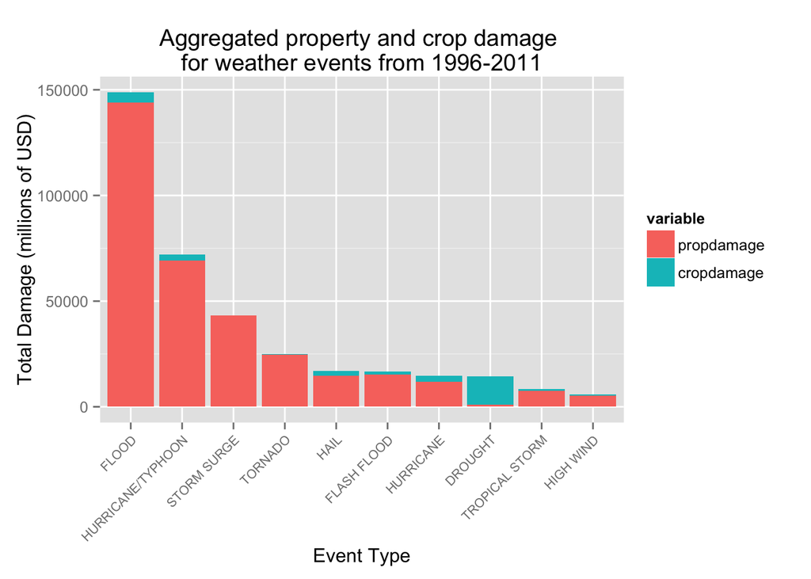

```r
df2 <- head(arrange(sumdf, desc(totaldamage)), n = 10)
df3 <- df2[,c("EVTYPE", "propdamage", "cropdamage")]
df4 <- melt(df3, id.vars = "EVTYPE")
ggplot(df4, aes(x = reorder(EVTYPE,-value), y = value/1000000, fill = variable)) +
    geom_bar(stat = "identity") +
    xlab("Event Type") +
    theme(axis.text.x = element_text(angle = 45, size=8,
                                     hjust = 1, vjust = 1)) +
     ylab("Total Damage (millions of USD)") +
    ggtitle("Aggregated property and crop damage \nfor weather events from 1996-2011")
```